# Risk Factor Analysis

## Outcome Variable

**Outcome Variable:** ever_stunted

## Predictor Variables

**Intervention Variable:** nchldlt5

**Adjustment Set:**

unadjusted

## Stratifying Variables

The analysis was stratified on these variable(s):

- agecat
- studyid
- country

## Data Summary

| agecat | studyid | country | nchldlt5 | ever_stunted | n_cell | n |
| --- | --- | --- | --- | --- | --- | --- |
| 0-24 months | ki1000108-IRC | INDIA | 1 | 0 | 35 | 291 |
| 0-24 months | ki1000108-IRC | INDIA | 1 | 1 | 54 | 291 |
| 0-24 months | ki1000108-IRC | INDIA | 2+ | 0 | 70 | 291 |
| 0-24 months | ki1000108-IRC | INDIA | 2+ | 1 | 132 | 291 |
| 0-24 months | ki1017093b-PROVIDE | BANGLADESH | 1 | 0 | 295 | 524 |
| 0-24 months | ki1017093b-PROVIDE | BANGLADESH | 1 | 1 | 217 | 524 |
| 0-24 months | ki1017093b-PROVIDE | BANGLADESH | 2+ | 0 | 9 | 524 |
| 0-24 months | ki1017093b-PROVIDE | BANGLADESH | 2+ | 1 | 3 | 524 |
| 0-24 months | ki1017093c-NIH-Crypto | BANGLADESH | 1 | 0 | 298 | 547 |
| 0-24 months | ki1017093c-NIH-Crypto | BANGLADESH | 1 | 1 | 243 | 547 |
| 0-24 months | ki1017093c-NIH-Crypto | BANGLADESH | 2+ | 0 | 4 | 547 |
| 0-24 months | ki1017093c-NIH-Crypto | BANGLADESH | 2+ | 1 | 2 | 547 |
| 0-24 months | ki1066203-TanzaniaChild2 | TANZANIA, UNITED REPUBLIC OF | 1 | 0 | 1077 | 1716 |
| 0-24 months | ki1066203-TanzaniaChild2 | TANZANIA, UNITED REPUBLIC OF | 1 | 1 | 560 | 1716 |
| 0-24 months | ki1066203-TanzaniaChild2 | TANZANIA, UNITED REPUBLIC OF | 2+ | 0 | 51 | 1716 |
| 0-24 months | ki1066203-TanzaniaChild2 | TANZANIA, UNITED REPUBLIC OF | 2+ | 1 | 28 | 1716 |
| 0-24 months | ki1112895-iLiNS-Zinc | BURKINA FASO | 1 | 0 | 711 | 1916 |
| 0-24 months | ki1112895-iLiNS-Zinc | BURKINA FASO | 1 | 1 | 362 | 1916 |
| 0-24 months | ki1112895-iLiNS-Zinc | BURKINA FASO | 2+ | 0 | 496 | 1916 |
| 0-24 months | ki1112895-iLiNS-Zinc | BURKINA FASO | 2+ | 1 | 347 | 1916 |
| 0-24 months | ki1148112-LCNI-5 | MALAWI | 1 | 0 | 145 | 454 |
| 0-24 months | ki1148112-LCNI-5 | MALAWI | 1 | 1 | 246 | 454 |
| 0-24 months | ki1148112-LCNI-5 | MALAWI | 2+ | 0 | 24 | 454 |
| 0-24 months | ki1148112-LCNI-5 | MALAWI | 2+ | 1 | 39 | 454 |
| 0-24 months | kiGH5241-JiVitA-3 | BANGLADESH | 1 | 0 | 17101 | 36063 |
| 0-24 months | kiGH5241-JiVitA-3 | BANGLADESH | 1 | 1 | 17683 | 36063 |
| 0-24 months | kiGH5241-JiVitA-3 | BANGLADESH | 2+ | 0 | 695 | 36063 |
| 0-24 months | kiGH5241-JiVitA-3 | BANGLADESH | 2+ | 1 | 584 | 36063 |
| 0-6 months | ki1000108-IRC | INDIA | 1 | 0 | 49 | 291 |
| 0-6 months | ki1000108-IRC | INDIA | 1 | 1 | 40 | 291 |
| 0-6 months | ki1000108-IRC | INDIA | 2+ | 0 | 118 | 291 |
| 0-6 months | ki1000108-IRC | INDIA | 2+ | 1 | 84 | 291 |
| 0-6 months | ki1017093b-PROVIDE | BANGLADESH | 1 | 0 | 384 | 524 |
| 0-6 months | ki1017093b-PROVIDE | BANGLADESH | 1 | 1 | 128 | 524 |
| 0-6 months | ki1017093b-PROVIDE | BANGLADESH | 2+ | 0 | 10 | 524 |
| 0-6 months | ki1017093b-PROVIDE | BANGLADESH | 2+ | 1 | 2 | 524 |
| 0-6 months | ki1017093c-NIH-Crypto | BANGLADESH | 1 | 0 | 386 | 547 |
| 0-6 months | ki1017093c-NIH-Crypto | BANGLADESH | 1 | 1 | 155 | 547 |
| 0-6 months | ki1017093c-NIH-Crypto | BANGLADESH | 2+ | 0 | 6 | 547 |
| 0-6 months | ki1017093c-NIH-Crypto | BANGLADESH | 2+ | 1 | 0 | 547 |
| 0-6 months | ki1066203-TanzaniaChild2 | TANZANIA, UNITED REPUBLIC OF | 1 | 0 | 1311 | 1716 |
| 0-6 months | ki1066203-TanzaniaChild2 | TANZANIA, UNITED REPUBLIC OF | 1 | 1 | 326 | 1716 |
| 0-6 months | ki1066203-TanzaniaChild2 | TANZANIA, UNITED REPUBLIC OF | 2+ | 0 | 66 | 1716 |
| 0-6 months | ki1066203-TanzaniaChild2 | TANZANIA, UNITED REPUBLIC OF | 2+ | 1 | 13 | 1716 |
| 0-6 months | ki1148112-LCNI-5 | MALAWI | 1 | 0 | 81 | 145 |
| 0-6 months | ki1148112-LCNI-5 | MALAWI | 1 | 1 | 41 | 145 |
| 0-6 months | ki1148112-LCNI-5 | MALAWI | 2+ | 0 | 13 | 145 |
| 0-6 months | ki1148112-LCNI-5 | MALAWI | 2+ | 1 | 10 | 145 |
| 0-6 months | kiGH5241-JiVitA-3 | BANGLADESH | 1 | 0 | 19644 | 36004 |
| 0-6 months | kiGH5241-JiVitA-3 | BANGLADESH | 1 | 1 | 15082 | 36004 |
| 0-6 months | kiGH5241-JiVitA-3 | BANGLADESH | 2+ | 0 | 826 | 36004 |
| 0-6 months | kiGH5241-JiVitA-3 | BANGLADESH | 2+ | 1 | 452 | 36004 |
| 6-24 months | ki1000108-IRC | INDIA | 1 | 0 | 35 | 167 |
| 6-24 months | ki1000108-IRC | INDIA | 1 | 1 | 14 | 167 |
| 6-24 months | ki1000108-IRC | INDIA | 2+ | 0 | 70 | 167 |
| 6-24 months | ki1000108-IRC | INDIA | 2+ | 1 | 48 | 167 |
| 6-24 months | ki1017093b-PROVIDE | BANGLADESH | 1 | 0 | 238 | 335 |
| 6-24 months | ki1017093b-PROVIDE | BANGLADESH | 1 | 1 | 89 | 335 |
| 6-24 months | ki1017093b-PROVIDE | BANGLADESH | 2+ | 0 | 7 | 335 |
| 6-24 months | ki1017093b-PROVIDE | BANGLADESH | 2+ | 1 | 1 | 335 |
| 6-24 months | ki1017093c-NIH-Crypto | BANGLADESH | 1 | 0 | 280 | 373 |
| 6-24 months | ki1017093c-NIH-Crypto | BANGLADESH | 1 | 1 | 88 | 373 |
| 6-24 months | ki1017093c-NIH-Crypto | BANGLADESH | 2+ | 0 | 3 | 373 |
| 6-24 months | ki1017093c-NIH-Crypto | BANGLADESH | 2+ | 1 | 2 | 373 |
| 6-24 months | ki1066203-TanzaniaChild2 | TANZANIA, UNITED REPUBLIC OF | 1 | 0 | 858 | 1145 |
| 6-24 months | ki1066203-TanzaniaChild2 | TANZANIA, UNITED REPUBLIC OF | 1 | 1 | 234 | 1145 |
| 6-24 months | ki1066203-TanzaniaChild2 | TANZANIA, UNITED REPUBLIC OF | 2+ | 0 | 38 | 1145 |
| 6-24 months | ki1066203-TanzaniaChild2 | TANZANIA, UNITED REPUBLIC OF | 2+ | 1 | 15 | 1145 |
| 6-24 months | ki1112895-iLiNS-Zinc | BURKINA FASO | 1 | 0 | 711 | 1916 |
| 6-24 months | ki1112895-iLiNS-Zinc | BURKINA FASO | 1 | 1 | 362 | 1916 |
| 6-24 months | ki1112895-iLiNS-Zinc | BURKINA FASO | 2+ | 0 | 496 | 1916 |
| 6-24 months | ki1112895-iLiNS-Zinc | BURKINA FASO | 2+ | 1 | 347 | 1916 |
| 6-24 months | ki1148112-LCNI-5 | MALAWI | 1 | 0 | 138 | 395 |
| 6-24 months | ki1148112-LCNI-5 | MALAWI | 1 | 1 | 205 | 395 |
| 6-24 months | ki1148112-LCNI-5 | MALAWI | 2+ | 0 | 23 | 395 |
| 6-24 months | ki1148112-LCNI-5 | MALAWI | 2+ | 1 | 29 | 395 |
| 6-24 months | kiGH5241-JiVitA-3 | BANGLADESH | 1 | 0 | 10465 | 13563 |
| 6-24 months | kiGH5241-JiVitA-3 | BANGLADESH | 1 | 1 | 2601 | 13563 |
| 6-24 months | kiGH5241-JiVitA-3 | BANGLADESH | 2+ | 0 | 365 | 13563 |
| 6-24 months | kiGH5241-JiVitA-3 | BANGLADESH | 2+ | 1 | 132 | 13563 |

The following strata were considered:

- agecat: 0-24 months, studyid: ki1000108-IRC, country: INDIA
- agecat: 0-24 months, studyid: ki1017093b-PROVIDE, country: BANGLADESH
- agecat: 0-24 months, studyid: ki1017093c-NIH-Crypto, country: BANGLADESH
- agecat: 0-24 months, studyid: ki1066203-TanzaniaChild2, country: TANZANIA, UNITED REPUBLIC OF
- agecat: 0-24 months, studyid: ki1112895-iLiNS-Zinc, country: BURKINA FASO
- agecat: 0-24 months, studyid: ki1148112-LCNI-5, country: MALAWI
- agecat: 0-24 months, studyid: kiGH5241-JiVitA-3, country: BANGLADESH
- agecat: 0-6 months, studyid: ki1000108-IRC, country: INDIA
- agecat: 0-6 months, studyid: ki1017093b-PROVIDE, country: BANGLADESH
- agecat: 0-6 months, studyid: ki1017093c-NIH-Crypto, country: BANGLADESH
- agecat: 0-6 months, studyid: ki1066203-TanzaniaChild2, country: TANZANIA, UNITED REPUBLIC OF
- agecat: 0-6 months, studyid: ki1148112-LCNI-5, country: MALAWI
- agecat: 0-6 months, studyid: kiGH5241-JiVitA-3, country: BANGLADESH
- agecat: 6-24 months, studyid: ki1000108-IRC, country: INDIA
- agecat: 6-24 months, studyid: ki1017093b-PROVIDE, country: BANGLADESH
- agecat: 6-24 months, studyid: ki1017093c-NIH-Crypto, country: BANGLADESH
- agecat: 6-24 months, studyid: ki1066203-TanzaniaChild2, country: TANZANIA, UNITED REPUBLIC OF
- agecat: 6-24 months, studyid: ki1112895-iLiNS-Zinc, country: BURKINA FASO
- agecat: 6-24 months, studyid: ki1148112-LCNI-5, country: MALAWI
- agecat: 6-24 months, studyid: kiGH5241-JiVitA-3, country: BANGLADESH

### Dropped Strata

Some strata were dropped due to rare outcomes:

- agecat: 0-24 months, studyid: ki1017093b-PROVIDE, country: BANGLADESH
- agecat: 0-24 months, studyid: ki1017093c-NIH-Crypto, country: BANGLADESH
- agecat: 0-6 months, studyid: ki1017093b-PROVIDE, country: BANGLADESH
- agecat: 0-6 months, studyid: ki1017093c-NIH-Crypto, country: BANGLADESH
- agecat: 6-24 months, studyid: ki1017093b-PROVIDE, country: BANGLADESH
- agecat: 6-24 months, studyid: ki1017093c-NIH-Crypto, country: BANGLADESH

## Methods Detail

We’re interested in the causal parameters $E[Y_a]$ for all values of $a \in \mathcal{A}$. These parameters represent the mean outcome if, possibly contrary to fact, we intervened to set all units to have $A=a$. Under the randomization and positivity assumptions, these are identified by the statistical parameters $\psi_a=E_W[E_{Y|A,W}(Y|A=a,W)]$. In addition, we’re interested in the mean of $Y$, $E[Y]$ under no intervention (the observed mean). We will estimate these parameters by using SuperLearner to fit the relevant likelihood factors – $E_{Y|A,W}(Y|A=a,W)$ and $p(A=a|W)$, and then updating our likelihood fit using a joint TMLE.

For unadjusted analyses ($W=\{\}$), initial likelihoods were estimated using Lrnr_glm to estimate the simple $E(Y|A)$ and Lrnr_mean to estimate $p(A)$. For adjusted analyses, a small library containing Lrnr_glmnet, Lrnr_xgboost, and Lrnr_mean was used.

Having estimated these parameters, we will then use the delta method to estimate relative risks and attributable risks relative to a prespecified baseline level of $A$.

# Results Detail

## Results Plots

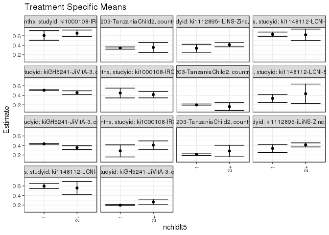

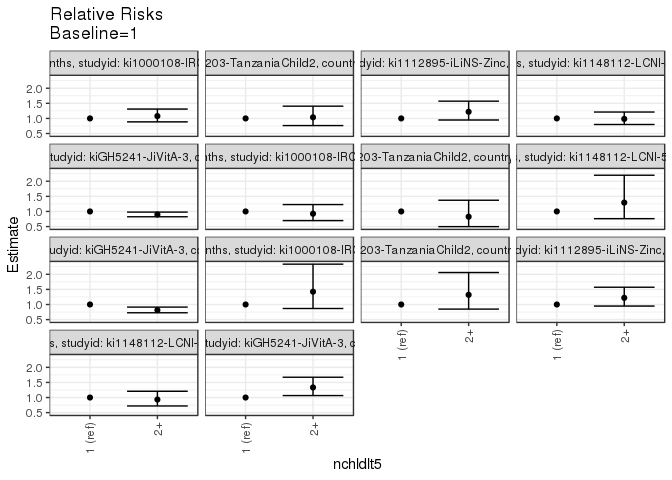

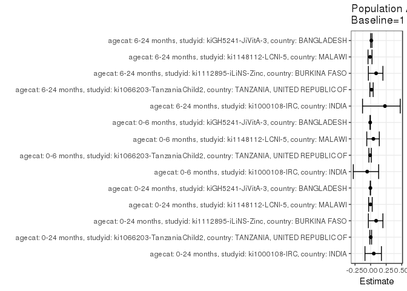

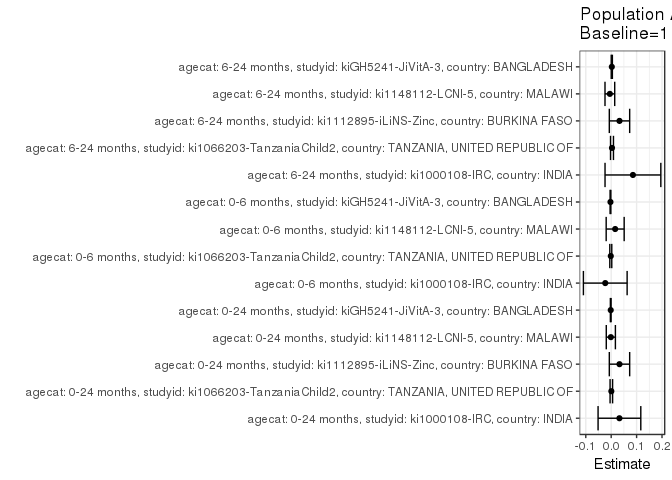

## Results Table

### Parameter: TSM

| agecat | studyid | country | intervention_level | baseline_level | estimate | ci_lower | ci_upper |
| --- | --- | --- | --- | --- | --- | --- | --- |
| 0-24 months | ki1000108-IRC | INDIA | 1 | NA | 0.6067416 | 0.5050836 | 0.7083996 |
| 0-24 months | ki1000108-IRC | INDIA | 2+ | NA | 0.6534653 | 0.5877292 | 0.7192015 |
| 0-24 months | ki1066203-TanzaniaChild2 | TANZANIA, UNITED REPUBLIC OF | 1 | NA | 0.3420892 | 0.3191011 | 0.3650773 |
| 0-24 months | ki1066203-TanzaniaChild2 | TANZANIA, UNITED REPUBLIC OF | 2+ | NA | 0.3544304 | 0.2489193 | 0.4599415 |
| 0-24 months | ki1112895-iLiNS-Zinc | BURKINA FASO | 1 | NA | 0.3373719 | 0.2536891 | 0.4210547 |
| 0-24 months | ki1112895-iLiNS-Zinc | BURKINA FASO | 2+ | NA | 0.4116251 | 0.3686793 | 0.4545710 |
| 0-24 months | ki1148112-LCNI-5 | MALAWI | 1 | NA | 0.6291560 | 0.5812254 | 0.6770867 |
| 0-24 months | ki1148112-LCNI-5 | MALAWI | 2+ | NA | 0.6190476 | 0.4989999 | 0.7390954 |
| 0-24 months | kiGH5241-JiVitA-3 | BANGLADESH | 1 | NA | 0.5083659 | 0.4990217 | 0.5177102 |
| 0-24 months | kiGH5241-JiVitA-3 | BANGLADESH | 2+ | NA | 0.4566067 | 0.4173235 | 0.4958899 |
| 0-6 months | ki1000108-IRC | INDIA | 1 | NA | 0.4494382 | 0.3459148 | 0.5529616 |
| 0-6 months | ki1000108-IRC | INDIA | 2+ | NA | 0.4158416 | 0.3477569 | 0.4839262 |
| 0-6 months | ki1066203-TanzaniaChild2 | TANZANIA, UNITED REPUBLIC OF | 1 | NA | 0.1991448 | 0.1797934 | 0.2184962 |
| 0-6 months | ki1066203-TanzaniaChild2 | TANZANIA, UNITED REPUBLIC OF | 2+ | NA | 0.1645570 | 0.0827712 | 0.2463427 |
| 0-6 months | ki1148112-LCNI-5 | MALAWI | 1 | NA | 0.3360656 | 0.2519560 | 0.4201752 |
| 0-6 months | ki1148112-LCNI-5 | MALAWI | 2+ | NA | 0.4347826 | 0.2314857 | 0.6380795 |
| 0-6 months | kiGH5241-JiVitA-3 | BANGLADESH | 1 | NA | 0.4343143 | 0.4252471 | 0.4433816 |
| 0-6 months | kiGH5241-JiVitA-3 | BANGLADESH | 2+ | NA | 0.3536776 | 0.3130491 | 0.3943061 |
| 6-24 months | ki1000108-IRC | INDIA | 1 | NA | 0.2857143 | 0.1588451 | 0.4125835 |
| 6-24 months | ki1000108-IRC | INDIA | 2+ | NA | 0.4067797 | 0.3178802 | 0.4956791 |
| 6-24 months | ki1066203-TanzaniaChild2 | TANZANIA, UNITED REPUBLIC OF | 1 | NA | 0.2142857 | 0.1899382 | 0.2386333 |
| 6-24 months | ki1066203-TanzaniaChild2 | TANZANIA, UNITED REPUBLIC OF | 2+ | NA | 0.2830189 | 0.1616908 | 0.4043470 |
| 6-24 months | ki1112895-iLiNS-Zinc | BURKINA FASO | 1 | NA | 0.3373719 | 0.2536891 | 0.4210547 |
| 6-24 months | ki1112895-iLiNS-Zinc | BURKINA FASO | 2+ | NA | 0.4116251 | 0.3686793 | 0.4545710 |
| 6-24 months | ki1148112-LCNI-5 | MALAWI | 1 | NA | 0.5976676 | 0.5457071 | 0.6496282 |
| 6-24 months | ki1148112-LCNI-5 | MALAWI | 2+ | NA | 0.5576923 | 0.4225297 | 0.6928549 |
| 6-24 months | kiGH5241-JiVitA-3 | BANGLADESH | 1 | NA | 0.1990663 | 0.1876806 | 0.2104519 |
| 6-24 months | kiGH5241-JiVitA-3 | BANGLADESH | 2+ | NA | 0.2655936 | 0.2070556 | 0.3241315 |

### Parameter: E(Y)

| agecat | studyid | country | intervention_level | baseline_level | estimate | ci_lower | ci_upper |
| --- | --- | --- | --- | --- | --- | --- | --- |
| 0-24 months | ki1000108-IRC | INDIA | NA | NA | 0.6391753 | 0.5839030 | 0.6944475 |
| 0-24 months | ki1066203-TanzaniaChild2 | TANZANIA, UNITED REPUBLIC OF | NA | NA | 0.3426573 | 0.3201957 | 0.3651190 |
| 0-24 months | ki1112895-iLiNS-Zinc | BURKINA FASO | NA | NA | 0.3700418 | 0.3180183 | 0.4220652 |
| 0-24 months | ki1148112-LCNI-5 | MALAWI | NA | NA | 0.6277533 | 0.5832380 | 0.6722686 |
| 0-24 months | kiGH5241-JiVitA-3 | BANGLADESH | NA | NA | 0.5065302 | 0.4972212 | 0.5158393 |
| 0-6 months | ki1000108-IRC | INDIA | NA | NA | 0.4261168 | 0.3692020 | 0.4830316 |
| 0-6 months | ki1066203-TanzaniaChild2 | TANZANIA, UNITED REPUBLIC OF | NA | NA | 0.1975524 | 0.1787088 | 0.2163961 |
| 0-6 months | ki1148112-LCNI-5 | MALAWI | NA | NA | 0.3517241 | 0.2737325 | 0.4297157 |
| 0-6 months | kiGH5241-JiVitA-3 | BANGLADESH | NA | NA | 0.4314521 | 0.4224311 | 0.4404731 |
| 6-24 months | ki1000108-IRC | INDIA | NA | NA | 0.3712575 | 0.2977607 | 0.4447542 |
| 6-24 months | ki1066203-TanzaniaChild2 | TANZANIA, UNITED REPUBLIC OF | NA | NA | 0.2174672 | 0.1935626 | 0.2413719 |
| 6-24 months | ki1112895-iLiNS-Zinc | BURKINA FASO | NA | NA | 0.3700418 | 0.3180183 | 0.4220652 |
| 6-24 months | ki1148112-LCNI-5 | MALAWI | NA | NA | 0.5924051 | 0.5438847 | 0.6409254 |
| 6-24 months | kiGH5241-JiVitA-3 | BANGLADESH | NA | NA | 0.2015041 | 0.1902251 | 0.2127831 |

### Parameter: RR

| agecat | studyid | country | intervention_level | baseline_level | estimate | ci_lower | ci_upper |
| --- | --- | --- | --- | --- | --- | --- | --- |
| 0-24 months | ki1000108-IRC | INDIA | 1 | 1 | 1.0000000 | 1.0000000 | 1.0000000 |
| 0-24 months | ki1000108-IRC | INDIA | 2+ | 1 | 1.0770077 | 0.8858209 | 1.3094584 |
| 0-24 months | ki1066203-TanzaniaChild2 | TANZANIA, UNITED REPUBLIC OF | 1 | 1 | 1.0000000 | 1.0000000 | 1.0000000 |
| 0-24 months | ki1066203-TanzaniaChild2 | TANZANIA, UNITED REPUBLIC OF | 2+ | 1 | 1.0360759 | 0.7635765 | 1.4058229 |
| 0-24 months | ki1112895-iLiNS-Zinc | BURKINA FASO | 1 | 1 | 1.0000000 | 1.0000000 | 1.0000000 |
| 0-24 months | ki1112895-iLiNS-Zinc | BURKINA FASO | 2+ | 1 | 1.2200933 | 0.9477079 | 1.5707664 |
| 0-24 months | ki1148112-LCNI-5 | MALAWI | 1 | 1 | 1.0000000 | 1.0000000 | 1.0000000 |
| 0-24 months | ki1148112-LCNI-5 | MALAWI | 2+ | 1 | 0.9839334 | 0.7988774 | 1.2118567 |
| 0-24 months | kiGH5241-JiVitA-3 | BANGLADESH | 1 | 1 | 1.0000000 | 1.0000000 | 1.0000000 |
| 0-24 months | kiGH5241-JiVitA-3 | BANGLADESH | 2+ | 1 | 0.8981852 | 0.8246516 | 0.9782757 |
| 0-6 months | ki1000108-IRC | INDIA | 1 | 1 | 1.0000000 | 1.0000000 | 1.0000000 |
| 0-6 months | ki1000108-IRC | INDIA | 2+ | 1 | 0.9252475 | 0.6974710 | 1.2274102 |
| 0-6 months | ki1066203-TanzaniaChild2 | TANZANIA, UNITED REPUBLIC OF | 1 | 1 | 1.0000000 | 1.0000000 | 1.0000000 |
| 0-6 months | ki1066203-TanzaniaChild2 | TANZANIA, UNITED REPUBLIC OF | 2+ | 1 | 0.8263182 | 0.4979820 | 1.3711376 |
| 0-6 months | ki1148112-LCNI-5 | MALAWI | 1 | 1 | 1.0000000 | 1.0000000 | 1.0000000 |
| 0-6 months | ki1148112-LCNI-5 | MALAWI | 2+ | 1 | 1.2937434 | 0.7612363 | 2.1987547 |
| 0-6 months | kiGH5241-JiVitA-3 | BANGLADESH | 1 | 1 | 1.0000000 | 1.0000000 | 1.0000000 |
| 0-6 months | kiGH5241-JiVitA-3 | BANGLADESH | 2+ | 1 | 0.8143356 | 0.7262042 | 0.9131625 |
| 6-24 months | ki1000108-IRC | INDIA | 1 | 1 | 1.0000000 | 1.0000000 | 1.0000000 |
| 6-24 months | ki1000108-IRC | INDIA | 2+ | 1 | 1.4237288 | 0.8679425 | 2.3354126 |
| 6-24 months | ki1066203-TanzaniaChild2 | TANZANIA, UNITED REPUBLIC OF | 1 | 1 | 1.0000000 | 1.0000000 | 1.0000000 |
| 6-24 months | ki1066203-TanzaniaChild2 | TANZANIA, UNITED REPUBLIC OF | 2+ | 1 | 1.3207547 | 0.8476469 | 2.0579242 |
| 6-24 months | ki1112895-iLiNS-Zinc | BURKINA FASO | 1 | 1 | 1.0000000 | 1.0000000 | 1.0000000 |
| 6-24 months | ki1112895-iLiNS-Zinc | BURKINA FASO | 2+ | 1 | 1.2200933 | 0.9477079 | 1.5707664 |
| 6-24 months | ki1148112-LCNI-5 | MALAWI | 1 | 1 | 1.0000000 | 1.0000000 | 1.0000000 |
| 6-24 months | ki1148112-LCNI-5 | MALAWI | 2+ | 1 | 0.9331144 | 0.7212933 | 1.2071408 |
| 6-24 months | kiGH5241-JiVitA-3 | BANGLADESH | 1 | 1 | 1.0000000 | 1.0000000 | 1.0000000 |
| 6-24 months | kiGH5241-JiVitA-3 | BANGLADESH | 2+ | 1 | 1.3341966 | 1.0646073 | 1.6720538 |

### Parameter: PAR

| agecat | studyid | country | intervention_level | baseline_level | estimate | ci_lower | ci_upper |
| --- | --- | --- | --- | --- | --- | --- | --- |
| 0-24 months | ki1000108-IRC | INDIA | 1 | NA | 0.0324337 | -0.0516378 | 0.1165052 |
| 0-24 months | ki1066203-TanzaniaChild2 | TANZANIA, UNITED REPUBLIC OF | 1 | NA | 0.0005682 | -0.0044047 | 0.0055411 |
| 0-24 months | ki1112895-iLiNS-Zinc | BURKINA FASO | 1 | NA | 0.0326699 | -0.0073786 | 0.0727184 |
| 0-24 months | ki1148112-LCNI-5 | MALAWI | 1 | NA | -0.0014027 | -0.0193429 | 0.0165375 |
| 0-24 months | kiGH5241-JiVitA-3 | BANGLADESH | 1 | NA | -0.0018357 | -0.0032385 | -0.0004328 |
| 0-6 months | ki1000108-IRC | INDIA | 1 | NA | -0.0233214 | -0.1093499 | 0.0627072 |
| 0-6 months | ki1066203-TanzaniaChild2 | TANZANIA, UNITED REPUBLIC OF | 1 | NA | -0.0015923 | -0.0054767 | 0.0022920 |
| 0-6 months | ki1148112-LCNI-5 | MALAWI | 1 | NA | 0.0156586 | -0.0197331 | 0.0510502 |
| 0-6 months | kiGH5241-JiVitA-3 | BANGLADESH | 1 | NA | -0.0028623 | -0.0043444 | -0.0013801 |
| 6-24 months | ki1000108-IRC | INDIA | 1 | NA | 0.0855432 | -0.0242390 | 0.1953254 |
| 6-24 months | ki1066203-TanzaniaChild2 | TANZANIA, UNITED REPUBLIC OF | 1 | NA | 0.0031815 | -0.0026073 | 0.0089704 |
| 6-24 months | ki1112895-iLiNS-Zinc | BURKINA FASO | 1 | NA | 0.0326699 | -0.0073786 | 0.0727184 |
| 6-24 months | ki1148112-LCNI-5 | MALAWI | 1 | NA | -0.0052626 | -0.0243723 | 0.0138472 |
| 6-24 months | kiGH5241-JiVitA-3 | BANGLADESH | 1 | NA | 0.0024378 | 0.0002197 | 0.0046559 |

### Parameter: PAF

| agecat | studyid | country | intervention_level | baseline_level | estimate | ci_lower | ci_upper |
| --- | --- | --- | --- | --- | --- | --- | --- |
| 0-24 months | ki1000108-IRC | INDIA | 1 | NA | 0.0507430 | -0.0905353 | 0.1737188 |
| 0-24 months | ki1066203-TanzaniaChild2 | TANZANIA, UNITED REPUBLIC OF | 1 | NA | 0.0016581 | -0.0129607 | 0.0160659 |
| 0-24 months | ki1112895-iLiNS-Zinc | BURKINA FASO | 1 | NA | 0.0882871 | -0.0361341 | 0.1977675 |
| 0-24 months | ki1148112-LCNI-5 | MALAWI | 1 | NA | -0.0022345 | -0.0312253 | 0.0259413 |
| 0-24 months | kiGH5241-JiVitA-3 | BANGLADESH | 1 | NA | -0.0036240 | -0.0064015 | -0.0008542 |
| 0-6 months | ki1000108-IRC | INDIA | 1 | NA | -0.0547300 | -0.2773268 | 0.1290754 |
| 0-6 months | ki1066203-TanzaniaChild2 | TANZANIA, UNITED REPUBLIC OF | 1 | NA | -0.0080603 | -0.0279079 | 0.0114041 |
| 0-6 months | ki1148112-LCNI-5 | MALAWI | 1 | NA | 0.0445194 | -0.0616130 | 0.1400415 |
| 0-6 months | kiGH5241-JiVitA-3 | BANGLADESH | 1 | NA | -0.0066341 | -0.0100851 | -0.0031949 |
| 6-24 months | ki1000108-IRC | INDIA | 1 | NA | 0.2304147 | -0.1296605 | 0.4757173 |
| 6-24 months | ki1066203-TanzaniaChild2 | TANZANIA, UNITED REPUBLIC OF | 1 | NA | 0.0146299 | -0.0123296 | 0.0408715 |
| 6-24 months | ki1112895-iLiNS-Zinc | BURKINA FASO | 1 | NA | 0.0882871 | -0.0361341 | 0.1977675 |
| 6-24 months | ki1148112-LCNI-5 | MALAWI | 1 | NA | -0.0088834 | -0.0416789 | 0.0228796 |
| 6-24 months | kiGH5241-JiVitA-3 | BANGLADESH | 1 | NA | 0.0120981 | 0.0010420 | 0.0230318 |